# 세계 행복 보고서 2023 분석

학과: 통계학과

학번: 202104241

이름: 추승원

### 목차

0. 데이터 준비하기
1. 2023 보고서 변경점
2. 세계에서 가장 행복한 10개국
3. 세계에서 가장 슬픈 10개국
4. 세계 지역별 행복지수
5. 상관관계 분석
6. 주요 요인

## 0. 데이터 준비하기

- 2021 보고서와 2023 보고서 국가 비교
- 결측치 확인
- 2023 보고서에 Regional indicator 열 추가

```r
library(tidyverse)
```

```r
library(ggchicklet)
library(cowplot)
library(waffle)
library(hrbrthemes)
library(ggalt)
library(GGally)
library(rwa)
```

```r
# 2021 보고서와 2023 보고서 불러오기
df_2021 <- read.csv("/Users/choo827/DataspellProjects/Test/world-happiness-report-2021.csv")
df_2023 <- read.csv("/Users/choo827/DataspellProjects/Test/WHR2023.csv")

# 2021 보고서에 있는 국가가 2023 보고서 안에 있으면 Yes를 반환, 없으면 ❌를 반환
ifelse(df_2021$Country.name %in% df_2023$Country.name, "Yes", "❌")
```

```
##   [1] "Yes" "Yes" "Yes" "Yes" "Yes" "Yes" "Yes" "Yes" "Yes" "Yes" "Yes" "Yes"
##  [13] "Yes" "Yes" "Yes" "Yes" "Yes" "❌"  "Yes" "Yes" "Yes" "Yes" "Yes" "Yes"
##  [25] "Yes" "Yes" "Yes" "Yes" "Yes" "Yes" "Yes" "Yes" "Yes" "Yes" "Yes" "Yes"
##  [37] "Yes" "Yes" "Yes" "Yes" "Yes" "Yes" "Yes" "Yes" "Yes" "Yes" "❌"  "Yes"
##  [49] "Yes" "Yes" "Yes" "Yes" "Yes" "Yes" "Yes" "Yes" "Yes" "Yes" "Yes" "Yes"
##  [61] "Yes" "Yes" "Yes" "Yes" "Yes" "Yes" "Yes" "Yes" "Yes" "Yes" "Yes" "Yes"
##  [73] "Yes" "❌"  "❌"  "Yes" "Yes" "Yes" "Yes" "❌"  "Yes" "Yes" "Yes" "Yes"
##  [85] "Yes" "Yes" "Yes" "Yes" "❌"  "❌"  "Yes" "Yes" "Yes" "Yes" "Yes" "Yes"
##  [97] "❌"  "Yes" "Yes" "Yes" "Yes" "Yes" "Yes" "❌"  "Yes" "Yes" "Yes" "Yes"
## [109] "Yes" "Yes" "Yes" "Yes" "Yes" "Yes" "Yes" "Yes" "Yes" "Yes" "Yes" "Yes"
## [121] "Yes" "Yes" "Yes" "Yes" "❌"  "Yes" "Yes" "Yes" "Yes" "❌"  "Yes" "Yes"
## [133] "Yes" "Yes" "Yes" "Yes" "Yes" "Yes" "Yes" "❌"  "❌"  "Yes" "❌"  "Yes"
## [145] "❌"  "Yes" "❌"  "Yes" "Yes"
```

```r
# 2023 보고서에 있는 국가가 2021 보고서 안에 있으면 Yes를 반환, 없으면 ❌를 반환
ifelse(df_2023$Country.name %in% df_2021$Country.name, "Yes", "❌")
```

```
##   [1] "Yes" "Yes" "Yes" "Yes" "Yes" "Yes" "Yes" "Yes" "Yes" "Yes" "Yes" "Yes"
##  [13] "Yes" "Yes" "Yes" "Yes" "Yes" "❌"  "Yes" "Yes" "Yes" "Yes" "Yes" "Yes"
##  [25] "Yes" "Yes" "Yes" "Yes" "Yes" "Yes" "Yes" "Yes" "Yes" "Yes" "Yes" "Yes"
##  [37] "Yes" "Yes" "Yes" "Yes" "Yes" "Yes" "Yes" "Yes" "Yes" "Yes" "Yes" "Yes"
##  [49] "Yes" "Yes" "Yes" "Yes" "Yes" "Yes" "Yes" "Yes" "Yes" "Yes" "Yes" "Yes"
##  [61] "Yes" "Yes" "Yes" "Yes" "Yes" "Yes" "Yes" "Yes" "Yes" "Yes" "Yes" "Yes"
##  [73] "Yes" "Yes" "Yes" "Yes" "Yes" "Yes" "Yes" "Yes" "Yes" "Yes" "Yes" "Yes"
##  [85] "Yes" "Yes" "Yes" "Yes" "Yes" "Yes" "Yes" "Yes" "Yes" "Yes" "Yes" "Yes"
##  [97] "Yes" "Yes" "❌"  "Yes" "Yes" "Yes" "Yes" "Yes" "Yes" "❌"  "Yes" "Yes"
## [109] "Yes" "Yes" "Yes" "Yes" "Yes" "Yes" "Yes" "Yes" "Yes" "Yes" "Yes" "Yes"
## [121] "Yes" "Yes" "Yes" "Yes" "Yes" "Yes" "Yes" "Yes" "Yes" "Yes" "Yes" "Yes"
## [133] "❌"  "Yes" "Yes" "Yes" "Yes"
```

```r
# 결측치 확인
sum(is.na(df_2021))
```

```
## [1] 0
```

```r
sum(is.na(df_2023))
```

```
## [1] 3
```

> State of Palestine의 데이터 3개가 NA인 것을 확인. 2021 보고서 데이터 값으로 입력

```r
# Regional indicator 열을 추가한 2023 보고서 불러오기
df_new2023 <- read.csv("/Users/choo827/DataspellProjects/Test/new_WHR2023.csv")

# 결측치 확인
sum(is.na(df_new2023))
```

```
## [1] 0
```

## 1. 2023 보고서 변경점

#### 이름이 변경된 국가

1. 🇨🇿Czech Republic ➡️ Czechia
2. 🇵🇸Palestinian Territories ➡️ State of Palestine
3. 🇹🇷Turkey ➡️ Turkiye

#### 기록이 추가된 국가

1. 🇨🇩Congo (Kinshasa)

#### 기록이 삭제된 국가

1. 🇦🇿Azerbaijan
2. 🇧🇾Belarus
3. Burundi
4. 🇭🇹Haiti
5. 🇰🇼Kuwait
6. 🇱🇸Lesotho
7. 🇱🇾Libya
8. 🇲🇻Maldives
9. 🇨🇾North Cyprus
10. 🇷🇼Rwanda
11. 🇸🇿Swaziland
12. 🇹🇲Turkmenistan
13. 🇾🇪Yemen

## 2. 세계에서 가장 행복한 10개국

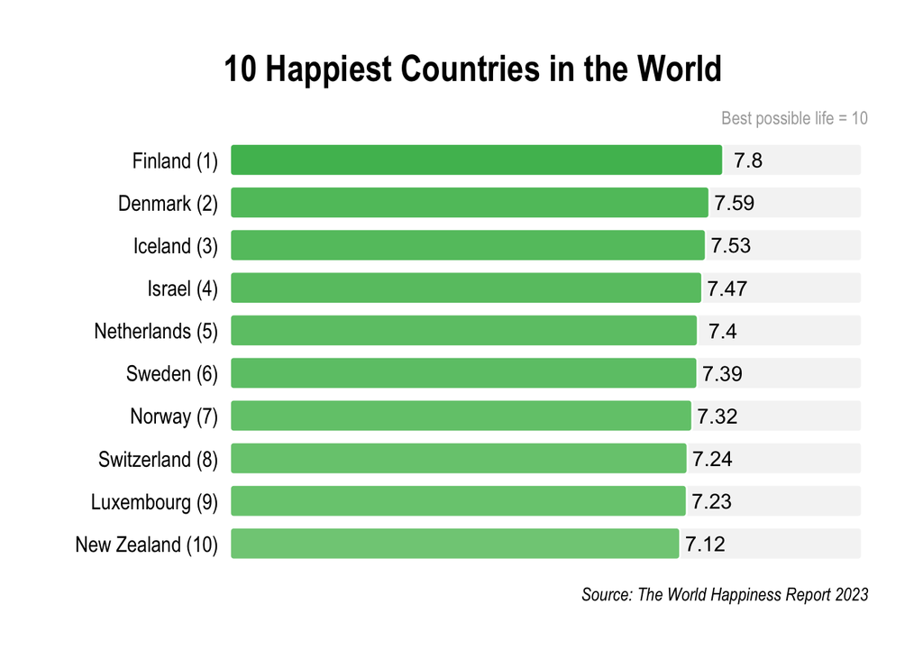

```r
dimensions <- c('Ladder.score', 'Logged.GDP.per.capita', 'Social.support', 'Healthy.life.expectancy', 'Freedom.to.make.life.choices', 'Generosity', 'Perceptions.of.corruption')

# map country to regions
country_region_dict <- df_new2023 %>%
  select(country = Country.name, region = Regional.indicator) %>%
  unique()

df_new2023_long <- df_new2023 %>%
  select(country = Country.name, all_of(dimensions)) %>%
  mutate(absence_of_corruption = 1 - Perceptions.of.corruption) %>%
  pivot_longer(cols = c(all_of(dimensions), 'absence_of_corruption'), names_to = 'dimension', values_to = 'score') %>%
  filter(dimension != "Perceptions.of.corruption")

df_new2023_tranformed <- df_new2023_long %>%
  group_by(dimension) %>%
  mutate(min_value = min(score),
         max_value = max(score)) %>%
  mutate(score_pct = (score - min_value) / (max_value - min_value)) %>%
  ungroup()

# get top 10
df_new2023_top10 <- df_new2023_tranformed %>%
  filter(dimension == "Ladder.score") %>%
  slice_max(score, n = 10) %>%
  mutate(cat = 'top_10',
         country_rank = rank(-score),
         country_label = paste0(country, ' (', country_rank, ')'))

ggplot(df_new2023_top10, aes(x = reorder(country_label, score))) +
  geom_chicklet(aes(y = 10, fill = 4.9), width = 0.75, radius = grid::unit(2, "pt")) +
  geom_chicklet(aes(y = score, fill = score), width = 0.75, radius = grid::unit(2, "pt")) +
  geom_text(aes(y = score), label = round(df_new2023_top10$score, 2), nudge_y = 0.4, size = 4) +
  scale_y_continuous(expand = c(0, 0.1), position = "right", limits = c(0, 10)) +
  scale_fill_gradient2(low = 'black', high = '#4dbb5f', mid = 'white', midpoint = 5) +
  coord_flip() +
  labs(y = "Best possible life = 10", x = '',
       title = "10 Happiest Countries in the World",
       caption = "Source: The World Happiness Report 2023") +
  theme_ipsum(grid = '') +
  theme(plot.title = element_text(size = 20),
        plot.subtitle = element_text(size = 14),
        plot.caption = element_text(size = 10),
        axis.title.x = element_text(size = 10, color = '#aaaaaa'),
        axis.text.y = element_text(size = 12, color = 'black'),
        axis.text.x = element_blank(),
        legend.position = 'None')
```

## 3. 세계에서 가장 슬픈 10개국

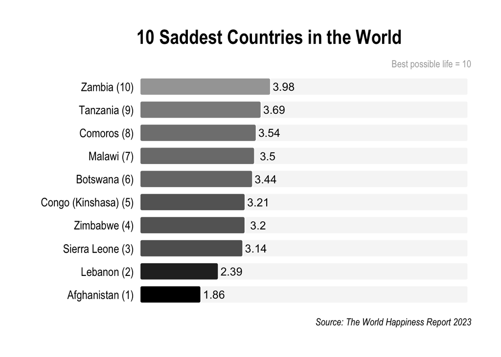

```r
# get bottom 10
df_new2023_bottom10 <- df_new2023_tranformed %>%
  filter(dimension == "Ladder.score") %>%
  mutate(country_rank = rank(score),
         country_label = paste0(country, ' (', country_rank, ')')) %>%
  slice_min(score, n = 10) %>%
  mutate(cat = 'bottom_10')

ggplot(df_new2023_bottom10, aes(x = reorder(country_label, score))) +
  geom_chicklet(aes(y = 10, fill = 4.9), width = 0.75, radius = grid::unit(2, "pt")) +
  geom_chicklet(aes(y = score, fill = score), width = 0.75, radius = grid::unit(2, "pt")) +
  geom_text(aes(y = score), label = round(df_new2023_bottom10$score, 2), nudge_y = 0.4, size = 4) +
  scale_y_continuous(expand = c(0, 0.1), position = "right", limits = c(0, 10)) +
  scale_fill_gradient2(low = 'black', high = '#7FB185', mid = 'white', midpoint = 5) +
  coord_flip() +
  labs(y = "Best possible life = 10", x = '',
       title = "10 Saddest Countries in the World",
       caption = "Source: The World Happiness Report 2023") +
  theme_ipsum(grid = '') +
  theme(plot.title = element_text(size = 20),
        plot.subtitle = element_text(size = 14),
        plot.caption = element_text(size = 10),
        axis.title.x = element_text(size = 10, color = '#aaaaaa'),
        axis.text.y = element_text(size = 12, color = 'black'),
        axis.text.x = element_blank(),
        legend.position = 'None')
```

## 4. 세계 지역별 행복지수

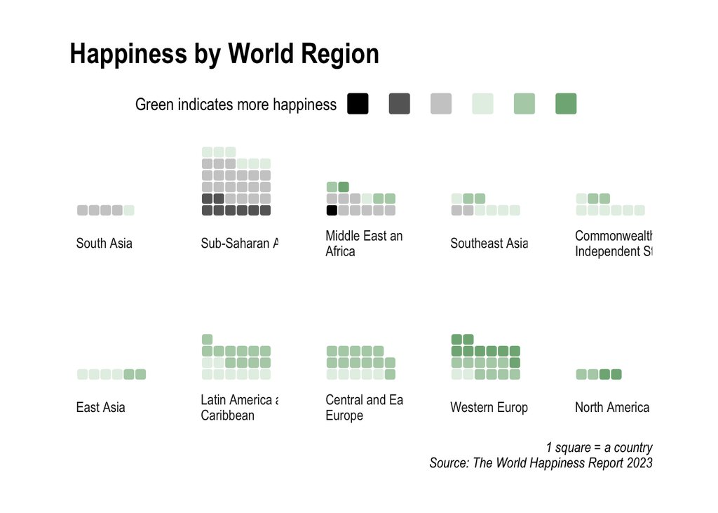

```r
df_waffle <- df_new2023_tranformed %>%
  filter(dimension == 'Ladder.score') %>%
  left_join(country_region_dict, by = 'country') %>%
  mutate(score_bin = cut(score, seq(2, 8, 1), right = FALSE)) %>%
  group_by(region) %>%
  mutate(region_avg = mean(score)) %>%
  ungroup() %>%
  mutate(region = reorder(region, region_avg)) %>%
  count(region, score_bin) %>%
  arrange(score_bin, n)

score_levels <- levels(df_waffle$score_bin)

pal <- colorRampPalette(c("black", "white", "#7FB185"))

ggplot(df_waffle, aes(fill = score_bin, values = n)) +
  geom_waffle(color = "white", size = 0.33, n_rows = 6, flip = TRUE, na.rm = FALSE, radius = unit(2, "pt")) +
  facet_wrap(~region, nrow = 2, strip.position = "bottom", labeller = label_wrap_gen()) +
  scale_x_discrete() +
  scale_y_continuous(labels = function(x) x * 6, # make this multiplyer the same as n_rows
                     expand = c(0, 0),
                     limits = c(0, 7)) +
  scale_fill_manual(
    name = "Green indicates more happiness",
    values = pal(6),
    labels = c('', '', '', '', '', '')
  ) +
  coord_equal() +
  labs(
    title = "Happiness by World Region",
    caption = "1 square = a country\nSource: The World Happiness Report 2023",
    y = "Country Count"
  ) +
  theme_ipsum(grid = '') +
  theme(plot.title = element_text(size = 20),
        plot.subtitle = element_text(size = 14),
        plot.caption = element_text(size = 10),
        axis.title.y = element_blank(),
        axis.title.x = element_text(size = 10),
        axis.text.x = element_text(size = 12),
        axis.text.y = element_blank(),
        strip.text.x = element_text(size = 10),
        legend.position = "top",
        legend.box = 'vertical',
        legend.title = element_text(size = 12),
        legend.text = element_text(size = 8)) +
  guides(fill = guide_legend(reverse = FALSE, nrow = 1, byrow = TRUE))
```

가장 행복한 지역은 북미와 서유럽임을 볼 수 있습니다.

## 5. 상관관계 분석

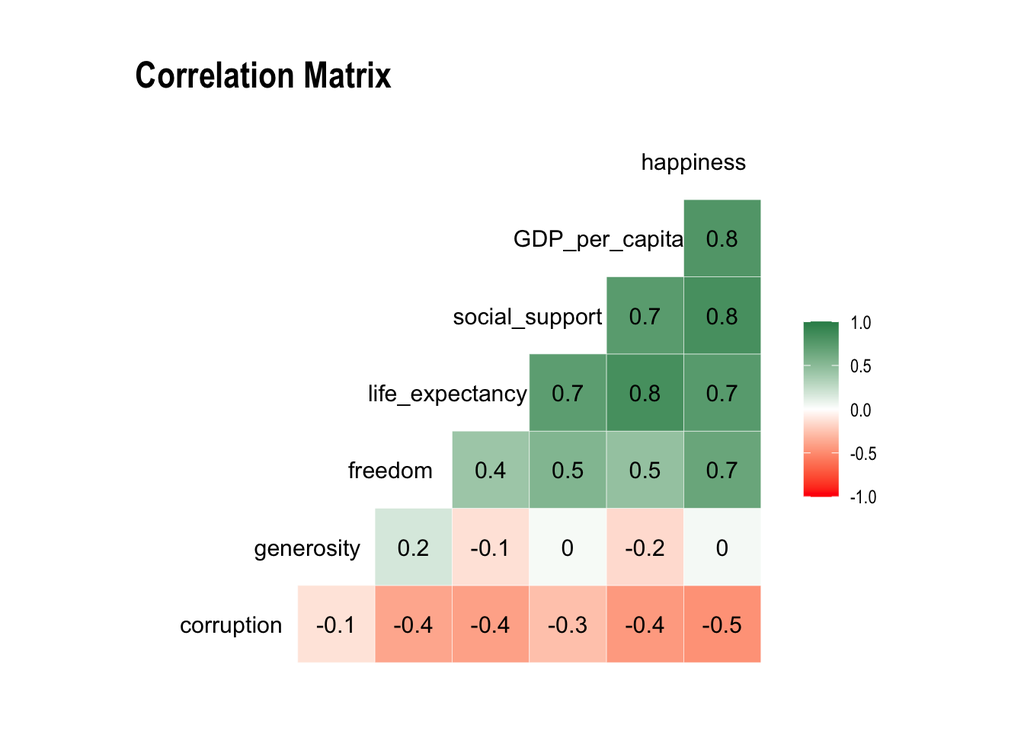

```r
df_cor <- df_new2023 %>%
  select(corruption = Perceptions.of.corruption,
         generosity = Generosity,
         freedom = Freedom.to.make.life.choices,
         life_expectancy = Healthy.life.expectancy,
         social_support = Social.support,
         GDP_per_capita = Logged.GDP.per.capita,
         happiness = Ladder.score
  )

ggcorr(df_cor,
       method = c("everything", "pearson"),
       size = 4, hjust = 0.77,
       low = '#ff0000', mid = 'white', high = "#2e8b57",
       label = TRUE, label_size = 4,
       layout.exp = 1) +
  labs(title = 'Correlation Matrix',) +
  theme_ipsum()
```

## 6. 주요 요인 분석

```r
predictors <- colnames(df_cor)[1:6]
outcome <- 'happiness'
rwa <- rwa(df_cor,
           outcome = outcome,
           predictors = predictors,
           applysigns = FALSE)

rsquare <- rwa$rsquare
(relative_weight <- rwa$result)
```

```
##         Variables Raw.RelWeight Rescaled.RelWeight Sign
## 1      corruption   0.068296632          8.2504593    -
## 2      generosity   0.005677267          0.6858327    +
## 3         freedom   0.160021408         19.3311159    +
## 4 life_expectancy   0.158147144         19.1046986    +
## 5  social_support   0.255621020         30.8798656    +
## 6  GDP_per_capita   0.180028409         21.7480279    +
```

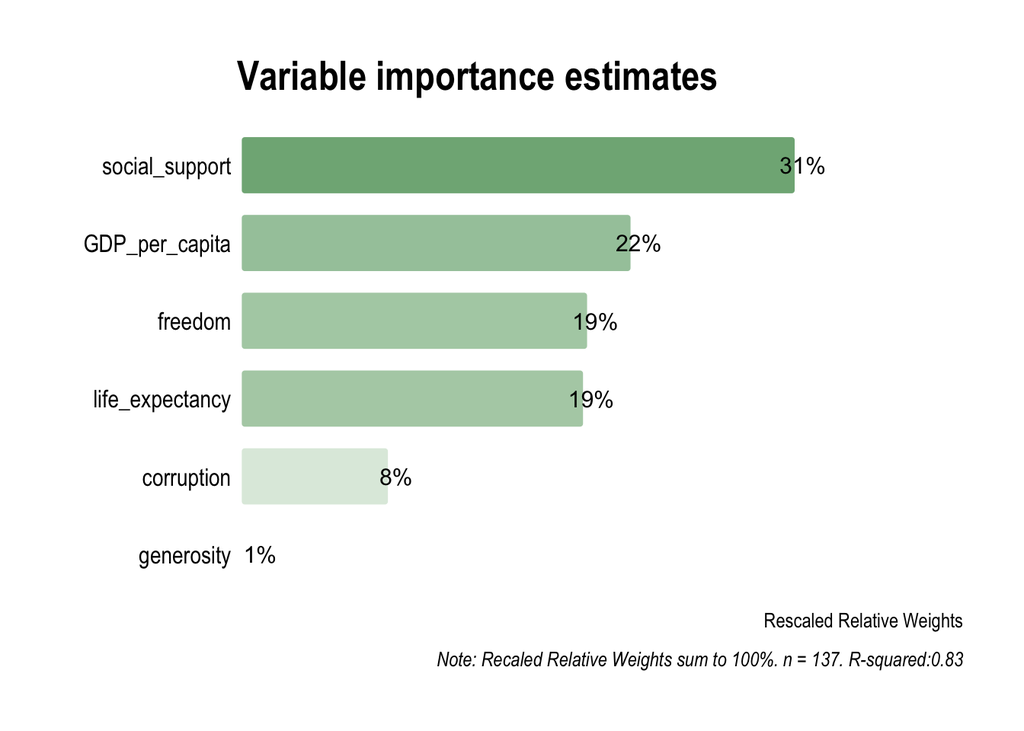

```r
n <- rwa$n

ggplot(relative_weight, aes(x = reorder(Variables, Rescaled.RelWeight), y = Rescaled.RelWeight, fill = Rescaled.RelWeight)) +
  geom_chicklet(width = 0.75, radius = grid::unit(2, "pt")) +
  geom_text(label = paste0(round(relative_weight$Rescaled.RelWeight, 0), "%"), nudge_y = 0.4, size = 4) +
  scale_y_continuous(expand = c(0, 0.2), limits = c(0, 40)) +
  scale_fill_gradient(low = 'white', high = '#7FB185') +
  coord_flip() +
  labs(y = "Rescaled Relative Weights", x = '',
       title = "Variable importance estimates",
       caption = paste0("Note: Recaled Relative Weights sum to 100%. n = ", n, '. R-squared:', round(rsquare, 2))) +
  theme_ipsum(grid = '') +
  theme(plot.title = element_text(size = 20),
        plot.subtitle = element_text(size = 14),
        plot.caption = element_text(size = 10),
        axis.title.x = element_text(size = 10),
        axis.text.y = element_text(size = 12, color = 'black'),
        axis.text.x = element_blank(),
        legend.position = 'None')
```

행복에 중요한 3가지 요인:

1. 사회적 지원
2. GDP
3. 자유, 기대수명 임을 볼 수 있습니다.

### 2023 세계 행복 보고서로 알게된 점

세계에서 가장 행복한 지역은 북미와 서유럽입니다.

행복에 중요한 3가지 주요 요인:

1. 사회적 지원
2. GDP
3. 자유, 기대수명